# projet datascience Rafika Cervera et Karim Belgacem VF

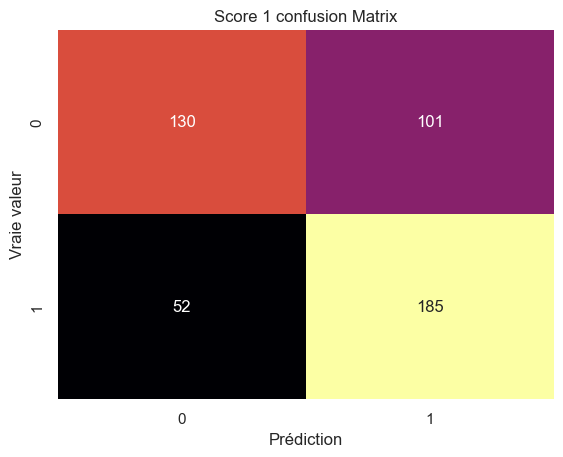

```python
import numpy as np
import pandas as pd
import seaborn as sns
import matplotlib.pyplot as plt
from sklearn.metrics import confusion_matrix

# Chargement des données
data = pd.read_excel('Credit_AES.xls')

# Transformation de la variable cible en binaire
data['y_num'] = data['Type de client'].map({'Mauvais client': 0, 'Bon client': 1})



y_true = data['y_num']

# Définition des seuils pour les scores
seuil_score1 = 0.5


data['Prediction_Score_1'] = np.where(data['Score 1'] >= seuil_score1, 1, 0)




y_pred_score1 = data['Prediction_Score_1']


# Normalisation des scores si nécessaire
data['Score 1'] /= 1000.0


# Définition des seuils pour les scores
seuil_score1 = 0.5

# Transformation de la variable cible en binaire
data['y_num'] = data['Type de client'].map({'Mauvais client': 0, 'Bon client': 1})

# Application des seuils pour obtenir des prédictions binaires pour les Scores 1 et 2
data['Prediction_Score_1'] = np.where(data['Score 1'] >= seuil_score1, 1, 0)


# Générer les prédictions pour le Score 3 à partir du modèle
# Assurez-vous que X est correctement défini pour votre modèle


# Calcul des matrices de confusion pour les trois scores
cm_score1 = confusion_matrix(data['y_num'], data['Prediction_Score_1'])
cm_score1


sns.heatmap(cm_score1, annot=True, fmt="d", cmap='inferno', cbar=False)
plt.xlabel('Prédiction')
plt.ylabel('Vraie valeur')
plt.title('Score 1 confusion Matrix')
plt.show()
```

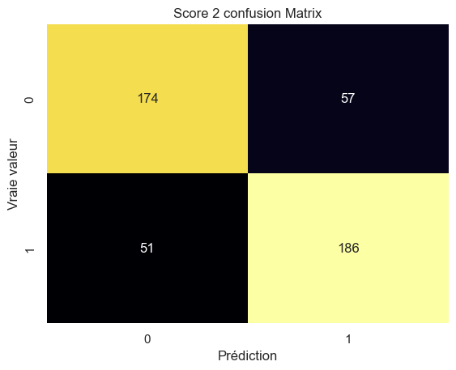

```python
seuil_score2 = 0.5


data['Prediction_Score_2'] = np.where(data['Score 2'] >= seuil_score2, 1, 0)




y_pred_score2 = data['Prediction_Score_2']


# Normalisation des scores si nécessaire
data['Score 2'] /= 1000.0


# Définition des seuils pour les scores
seuil_score2 = 0.5


# Application des seuils pour obtenir des prédictions binaires pour les Scores 1 et 2
data['Prediction_Score_2'] = np.where(data['Score 2'] >= seuil_score2, 1, 0)


# Générer les prédictions pour le Score 3 à partir du modèle
# Assurez-vous que X est correctement défini pour votre modèle


# Calcul des matrices de confusion pour les trois scores
cm_score2 = confusion_matrix(data['y_num'], data['Prediction_Score_2'])
cm_score2


sns.heatmap(cm_score2, annot=True, fmt="d", cmap='inferno', cbar=False)
plt.xlabel('Prédiction')
plt.ylabel('Vraie valeur')
plt.title('Score 2 confusion Matrix')
plt.show()
```

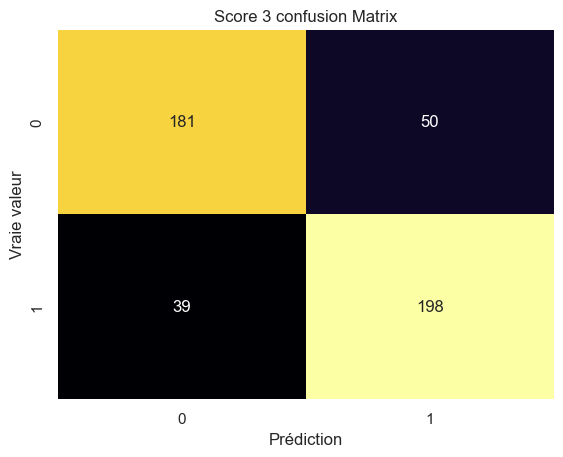

```python
from sklearn.linear_model import LogisticRegression

# Création du modèle
model = LogisticRegression()

# Entraînement du modèle
model.fit(X_train, y_train)

# Obtention des scores de décision
decision_scores = model.decision_function(data_reg_bin_app)

# Normalisation des scores de décision dans la plage [0, 1] en utilisant la fonction sigmoïde
y_proba_score3 = 1 / (1 + np.exp(-decision_scores))

# Définition du seuil pour Score 3
seuil_score3 = 0.5

# Prédiction binaire en fonction du seuil
data['Prediction_Score_3'] = np.where(y_proba_score3 >= seuil_score3, 1, 0)


data['Score 3'] = np.round(y_proba_score3 * 1000).astype(int)

# Normalisation des scores si nécessaire
data['Score 3'] /= 1000.0

# Calcul de la matrice de confusion pour Score 3
cm_score3 = confusion_matrix(data['y_num'], data['Prediction_Score_3'])

# Affichage de la matrice de confusion
sns.heatmap(cm_score3, annot=True, fmt="d", cmap='inferno', cbar=False)
plt.xlabel('Prédiction')
plt.ylabel('Vraie valeur')
plt.title('Score 3 confusion Matrix')
plt.show()
```

Les résultats des modèles de risque de crédit fournissent un aperçu de la probabilité de défaut et des facteurs influençant la solvabilité. Les prêteurs peuvent utiliser ces résultats pour prendre des décisions éclairées concernant l'approbation des prêts, la tarification des risques et la gestion du portefeuille. L'interprétation des résultats du modèle est essentielle pour comprendre l'impact des différentes variables sur le risque de crédit. L'évaluation des performances du modèle et des mesures d'adéquation. Les performances du modèle peuvent être évaluées en comparant les probabilités prédites avec les résultats observés et en évaluant dans quelle mesure le modèle fait la distinction entre les deux classes du résultat. Certaines des mesures courantes de l'adéquation de l'ajustement sont :

La matrice de confusion, qui montre le nombre de vrais positifs, de faux positifs, de vrais négatifs et de faux négatifs pour une valeur seuil donnée de la probabilité prédite.

La précision, qui est la proportion d'observations correctement classées, calculée comme (TP + TN) / (TP + FP + TN + FN).

La sensibilité, qui est la proportion de résultats positifs correctement prédits, calculée comme TP / (TP + FN).

La spécificité, qui est la proportion de résultats négatifs correctement prédits, calculée comme TN / (TN + FP).

La courbe ROC, qui trace la sensibilité par rapport au taux de faux positifs (1 - spécificité) pour différentes valeurs seuil de la probabilité prédite, et montre le compromis entre le taux de vrais positifs et le taux de faux positifs.

L'AUC, qui est l'aire sous la courbe ROC, et représente la probabilité que le modèle classe un résultat positif choisi au hasard plus haut qu'un résultat négatif choisi au hasard. L'AUC varie de 0,5 (estimation aléatoire) à 1 (discrimination parfaite).